# Explore the Macrophage FCOS classifier

We begin by loading the metadata associatedd with the optimal clasifier as determined in experiment 1.

```r
macro <- readRDS(macro, file=file.path(CANDESCENCE, "performance/grace_macro", "optimal_classifier.rds"))
```

Now that we have chosen our best classifiers, we are ready to load the events associated with the test data. The following chunk of code assumes that ${\tt generate\_test\_objects.py}$ has already been run.

```r
test_events <- read_csv(file.path(macro['SAVE_RESULTS'],
                                  paste0("test_events_",
                                  macro['numba'], "_thresh_", macro['opt_threshold'], ".csv")))
```

```r
te <- test_events

tmp_<- str_split(te$filename, pattern="_", simplify=TRUE)

for (i in 1:nrow(tmp_)) {
  if (tmp_[i,1]=="TC") { tmp_[i, 2:6 ] <- tmp_[i, 3:7]; tmp_[i, 7]<- "" }
}

te$type<-ifelse(tmp_[,1]=="both", "macro", tmp_[,1])
te$replicate<-as.integer(str_split(tmp_[,2], pattern="[A-Z]+", simplify=TRUE)[,2])
te$plate <- as.integer(str_split(tmp_[,3], pattern="[A-Z]+", simplify=TRUE)[,2])
te$position<-tmp_[,4]
te <- te %>% separate( col=position, into=c("row", "column"), sep=1 )

te <- te %>% relocate(event, experiment, type, threshold, gt_class, dt_class,
                             plate, row, column,replicate, bbox_1, bbox_2, bbox_3, bbox_4)

te <- te %>% mutate( area = (bbox_3 - bbox_1)*(bbox_4 - bbox_2))
print(te)
```

| event | experiment | type | threshold | gt_class | dt_class | plate | row | column | replicate | bbox_1 | bbox_2 | bbox_3 | bbox_4 | ...1 | filename | index | area |
| --- | --- | --- | --- | --- | --- | --- | --- | --- | --- | --- | --- | --- | --- | --- | --- | --- | --- |
| predict | slow_lax | macro | 0.3 | NA | 0 | 22 | C | 7 | 2 | 1 | 447 | 21 | 505 | 0 | both_R2_P22_C7_1_00d00h28m.bmp | 0 | 1160 |
| predict | slow_lax | macro | 0.3 | NA | 0 | 22 | C | 7 | 2 | 458 | 527 | 478 | 593 | 1 | both_R2_P22_C7_1_00d00h28m.bmp | 1 | 1320 |
| predict | slow_lax | macro | 0.3 | NA | 0 | 22 | C | 7 | 2 | 778 | 667 | 799 | 703 | 2 | both_R2_P22_C7_1_00d00h28m.bmp | 2 | 756 |
| predict | slow_lax | macro | 0.3 | NA | 0 | 22 | C | 7 | 2 | 16 | 3 | 76 | 29 | 3 | both_R2_P22_C7_1_00d00h28m.bmp | 3 | 1560 |
| predict | slow_lax | macro | 0.3 | NA | 1 | 22 | C | 7 | 2 | 1 | 445 | 22 | 506 | 4 | both_R2_P22_C7_1_00d00h28m.bmp | 4 | 1281 |
| predict | slow_lax | macro | 0.3 | NA | 1 | 22 | C | 7 | 2 | 457 | 528 | 479 | 595 | 5 | both_R2_P22_C7_1_00d00h28m.bmp | 5 | 1474 |
| predict | slow_lax | macro | 0.3 | NA | 1 | 22 | C | 7 | 2 | 548 | 387 | 581 | 437 | 6 | both_R2_P22_C7_1_00d00h28m.bmp | 6 | 1650 |
| predict | slow_lax | macro | 0.3 | NA | 1 | 22 | C | 7 | 2 | 385 | 760 | 422 | 797 | 7 | both_R2_P22_C7_1_00d00h28m.bmp | 7 | 1369 |
| predict | slow_lax | macro | 0.3 | NA | 1 | 22 | C | 7 | 2 | 603 | 320 | 637 | 345 | 8 | both_R2_P22_C7_1_00d00h28m.bmp | 8 | 850 |
| predict | slow_lax | macro | 0.3 | NA | 1 | 22 | C | 7 | 2 | 16 | 3 | 76 | 29 | 9 | both_R2_P22_C7_1_00d00h28m.bmp | 9 | 1560 |

[output cut: 990 more lines]

```r
write_csv(te, file.path(macro['SAVE_RESULTS'],
                                  paste0("refined_test_events_",
                                  macro['numba'], "_thresh_", macro['opt_threshold'], ".csv")))
filename2prcr <- te %>% select(filename, plate, row, column, replicate) %>% distinct
```

We asked what the distribution of sizes is for each of the classes across all immages. For the important classes, there are significnt differences overall. Specifically there is a slight increase in the avearge size with filementation.

```r
szs <- te %>% group_by(dt_class) %>% summarise(A_mean = mean(area), A_med=median(area), A_min=min(area), A_max=max(area))
print(szs)
```

| A_mean | A_med | A_min | A_max |
| --- | --- | --- | --- |
| 1569.994 | 1344 | 312 | 15470 |

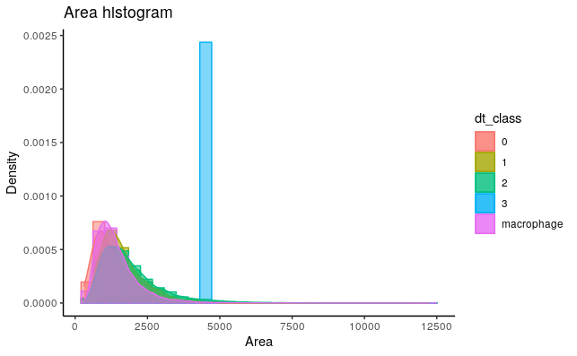

```r
ggplot(te %>% filter(dt_class %in% macro$important), aes(x=area, color=dt_class, fill=dt_class)) +
geom_histogram(aes(y=..density..), position="identity", alpha=0.5)+
geom_density(alpha=0.6)+
#scale_color_manual(values=c("#999999", "#E69F00", "#56B4E9"))+
#scale_fill_manual(values=c("#999999", "#E69F00", "#56B4E9"))+
labs(title="Area histogram",x="Area", y = "Density")+
theme_classic()
```

We next build summaries of each individual image. For this we will only consider the so-called ``important’’ classes.

```r
te <- te %>% ungroup
img_summary <- te %>% filter(dt_class %in% macro$important) %>%
  group_by(filename, dt_class) %>%
  dplyr::summarise( n=n(), A_mean = mean(area), A_med=median(area), A_min=min(area), A_max=max(area))
img_summary <- img_summary %>% ungroup %>% group_by(filename) %>%
    mutate(total = sum(n))
img_summary<- img_summary %>% mutate(freq=n/total)
img_summary <- img_summary %>% relocate(filename, dt_class, freq )
print(img_summary)
```

| filename | dt_class | freq | n | A_mean | A_med | A_min | A_max | total |
| --- | --- | --- | --- | --- | --- | --- | --- | --- |
| both_R1_P1_H11_1_00d00h00m.bmp | 0 | 1.536413e-04 | 3 | 1097.3333 | 1036.0 | 896 | 1360 | 19526 |
| both_R1_P1_H11_1_00d00h00m.bmp | 1 | 2.560688e-03 | 50 | 1893.2600 | 1565.0 | 744 | 5940 | 19526 |
| both_R1_P1_H11_1_00d00h00m.bmp | 2 | 1.536413e-03 | 30 | 2723.6667 | 2305.5 | 828 | 5832 | 19526 |
| both_R1_P1_H11_1_00d00h00m.bmp | macrophage | 3.072826e-03 | 60 | 1885.7500 | 1562.0 | 527 | 5829 | 19526 |
| both_R1_P1_H6_1_00d00h00m.bmp | 0 | 1.024275e-04 | 2 | 1777.0000 | 1777.0 | 1209 | 2345 | 19526 |
| both_R1_P1_H6_1_00d00h00m.bmp | 1 | 9.218478e-04 | 18 | 2072.8333 | 1798.0 | 832 | 4347 | 19526 |
| both_R1_P1_H6_1_00d00h00m.bmp | 2 | 4.609239e-04 | 9 | 1890.1111 | 2106.0 | 1248 | 2666 | 19526 |
| both_R1_P1_H6_1_00d00h00m.bmp | macrophage | 7.323569e-03 | 143 | 1689.4126 | 1480.0 | 374 | 6156 | 19526 |
| both_R1_P10_A9_1_00d00h00m.bmp | 0 | 1.024275e-04 | 2 | 1140.0000 | 1140.0 | 1056 | 1224 | 19526 |
| both_R1_P10_A9_1_00d00h00m.bmp | 1 | 2.202192e-03 | 43 | 1522.8140 | 1452.0 | 504 | 4329 | 19526 |

[output cut: 379 more lines]

To get a visualization of the differences, we will use some clustering methods designed specifically for CoDa data.

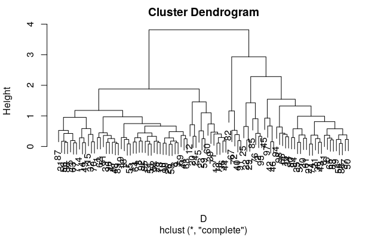

```r
library(robCompositions) # for the aitchion distance fnc aDist
freqs <- img_summary %>%
            ungroup %>% select(filename, dt_class, n) %>% group_by(filename) %>%
            pivot_wider(names_from=dt_class, values_from=n)
for (i in 2:6) {
  freqs[,i] <- freqs[,i] + 1 # add a peudocount to avoid 0s
  freqs[is.na(freqs[,i]),i] <- 1
}
freqs <- freqs %>% mutate( tot = `0`+`1`+`2`+`3`+macrophage) %>%
    mutate(f0=`0`/tot, f1=`1`/tot, f2=`2`/tot, f3=`3`/tot, fmacro=macrophage/tot) %>%
    select(filename, f0:fmacro)
M <- as.matrix(freqs[, c('f0', 'f1', 'f2', 'f3', 'fmacro')])
D <- aDist(M); C <- hclust(D); plot(C)
```

Two dimensional k-means clustering represents an alternative view. We re-use the matrix $M$ from above.

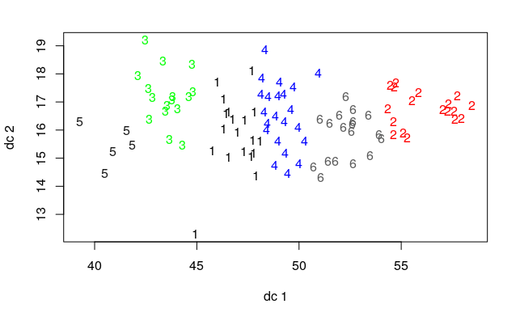

```r
km <- kmeans(M, 6)
#dp = discrproj(data, km$clustering)
library(fpc)
plotcluster(M, km$cluster)      #from library(fpc)
```

We also explore using principal component analysis (PCA).

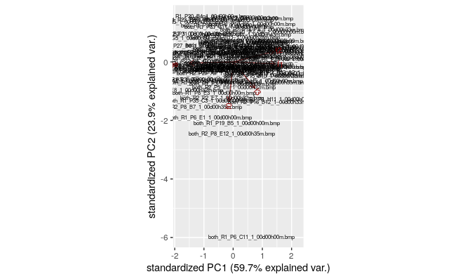

```r
library(ggbiplot)
TT <- as.matrix(tmp[2:ncol(tmp)])
rownames(TT)<-pull(tmp, filename)
tmp.pca <- prcomp(TT, center = TRUE,scale. = TRUE)
ggbiplot(tmp.pca, labels=rownames(TT), labels.size=2)
```

We ask if there is greater concordance (measured with the Aitkinson distance) between replicates than between non-replicates.

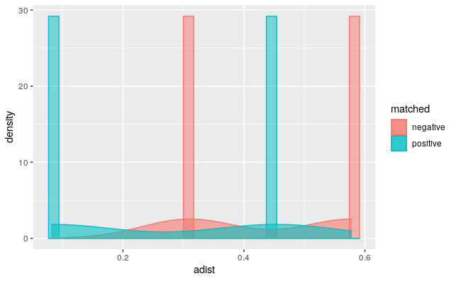

```r
rand_samples <- 10

reps <- freqs %>% inner_join(filename2prcr, by="filename") %>%
  group_by(plate, row, column) %>% dplyr::mutate(n=n()) %>% filter(n>1)
reps <- reps %>% ungroup %>% group_by(plate, row, column, replicate)
rep1 <- reps[1:(nrow(reps)/2),]; rep2 <- reps[((nrow(reps)/2)+1):nrow(reps),]
reps1 <- as.matrix(rep1[2:6]); rownames(reps1) <- pull(rep1, filename)
reps2 <- as.matrix(rep2[2:6]); rownames(reps2) <- pull(rep2, filename)
positive_reps <- unlist(lapply( 1:nrow(reps1), FUN=function(i) aDist(reps1[i,], reps2[i,]) ))
negative_reps <- c()
for (i in 1:nrow(reps1)) {
  if (rand_samples > (nrow(reps1)-1)) {
    idx <- setdiff(1:nrow(reps1), i)
  } else {
    idx <- sample( setdiff(1:nrow(reps1), i), size = rand_samples)
  }
  negative_reps <- c(negative_reps,
                       unlist(lapply( idx, FUN=function(j) aDist(reps1[i,], reps2[j,]) )))
}

tib <- tibble(matched=c(rep("positive", times=length(positive_reps)),
                       rep("negative", times=length(negative_reps))),
              adist = c(positive_reps, negative_reps) )

ggplot(tib, aes(x=adist, color=matched, fill=matched)) +
  geom_histogram(aes(y=..density..), position="identity", alpha=0.5)+
  geom_density(alpha=0.6)
```

We next look at the distribution of the number of events (restricted to ``important’’ events) across the images. Our first analysis considers all import event together.

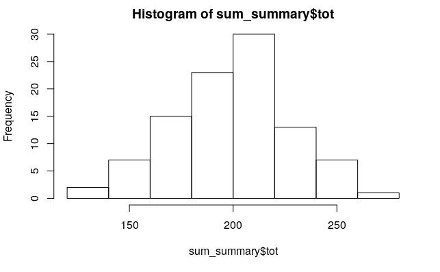

```r
sum_summary <- img_summary %>% ungroup %>% group_by(filename) %>%  dplyr::summarize(tot=sum(n))
hist(sum_summary$tot)
```

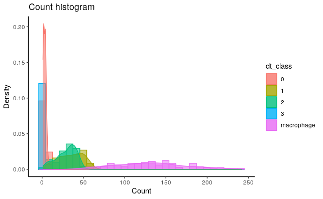

```r
h <- img_summary %>% ungroup
ggplot(h, aes(x=n, color=dt_class, fill=dt_class)) +
geom_histogram(aes(y=..density..), position="identity", alpha=0.5)+
geom_density(alpha=0.6)+
#scale_color_manual(values=c("#999999", "#E69F00", "#56B4E9"))+
#scale_fill_manual(values=c("#999999", "#E69F00", "#56B4E9"))+
labs(title="Count histogram",x="Count", y = "Density")+
theme_classic()
```

We explore several ``top 10’’ lists. First, we look at the highet and lowest relative frequencies per class.

```r
top_freqs <- freqs %>%
   inner_join(filename2prcr, by="filename") %>%
   relocate(plate, row, column, replicate, f0, f1, f2, f3, fmacro)

top_freqs <- top_freqs %>% left_join(grace,
                  by=c("plate"="plate", "row"="row", "column"="column"))

klasses <- c('f0', 'f1', 'f2', 'f3', 'fmacro')

twibble <- tibble(klass=character(), direction=character(),
                  common=character(),
                  feature_name=character(),
                  description=character(),
                  statistic=numeric(), filename=character() )

for (i in 1:5) {
  tmp <-  top_freqs %>% arrange(.[,klasses[i]]) %>%
    select(common, feature_name, description, klasses[i], filename) %>%
    relocate(common, feature_name, description, klasses[i]) %>%
    dplyr::rename(statistic=klasses[i]) %>%
    head(n=10)
  tmp$klass <- klasses[i]
  tmp$direction <- "low"
  twibble <- add_row(twibble, tmp)

  tmp <-  top_freqs %>% arrange(.[,klasses[i]]) %>%
    select(common, feature_name, description, klasses[i], filename) %>%
    relocate(common, feature_name, description, klasses[i]) %>%
    dplyr::rename(statistic=klasses[i]) %>%
    tail(n=10)
  tmp$klass <- klasses[i]
  tmp$direction <- "high"
  twibble <- add_row(twibble, tmp)
}
print(twibble, n=Inf)
```

| klass | direction | common | feature_name | description | statistic | filename |
| --- | --- | --- | --- | --- | --- | --- |
| f0 | low | NOC2 | CR_05520W_A | Putative nucleolar complex protein; Hap43-induced; transposon mutation affects filamentous growth; mutation confers hypersensitivity to 5-fluorouracil (5-FU), tubercidin (7-deazaadenosine); repressed … | 0.004784689 | both_R1_P11_A11_1_00d00h00m.bmp |
| f0 | low | GLR1 | C5_01520C_A | Glutathione reductase; upregulated by human neutrophils; oxidative stress-induced regulation via Cap1p; overexpression correlates with multidrug resistance in a cap1 mutant, farnesol induced; stationa… | 0.005000000 | both_R1_P22_G4_1_00d00h00m.bmp |
| f0 | low | MIT1 | C2_09150W_A | Mannosylinositol phosphorylceramide (MIPC) synthase catalytic subunit; sphingolipid biosynthesis; fluconazole, caspofungin induced; macrophage-repressed; Spider biofilm induced | 0.005714286 | both_R2_P14_F4_1_00d00h33m.bmp |
| f0 | low | GUK1 | C5_03790W_A | Putative guanylate kinase; identified in extracts from biofilm and planktonic cells; protein level decrease in stationary phase cultures; Hap43p-induced gene | 0.006578947 | both_R1_P15_D8_1_00d00h00m.bmp |
| f0 | low | ERG27 | CR_01140C_A | 3-Keto sterol reductase of ergosterol biosynthesis; acts in C-4 sterol demethylation with Erg25p and Erg26p; possible drug target, essential for viability; functional homolog of S. cerevisiae Erg27p | 0.007604563 | both_R1_P23_H5_1_00d00h00m.bmp |
| f0 | low | YBL053 | C5_01460W_A | Ortholog(s) have protein heterodimerization activity | 0.007782101 | both_R1_P20_B4_1_00d00h00m.bmp |
| f0 | low | RIB5 | C5_05300W_A | Putative riboflavin synthase; fungal-specific (no human or murine homolog); farnesol-downregulated; protein present in exponential and stationary growth phase yeast cultures | 0.007812500 | both_R1_P23_E3_1_00d00h00m.bmp |
| f0 | low | STB3 | C2_09010W_A | Putative SIN3-binding protein 3 homolog; caspofungin induced; macrophage/pseudohyphal-repressed; rat catheter biofilm induced | 0.008658009 | both_R1_P5_B6_1_00d00h00m.bmp |
| f0 | low | CRT10 | C6_02790C_A | Putative transcriptional regulator of ribonucleotide reductase genes; Spider biofilm induced | 0.008968610 | both_R2_P31_D8_1_00d00h43m.bmp |
| f0 | low | YPD1 | C1_07240W_A | Phosphohistidine intermediate protein in a phosphorelay signal transduction pathway; residue His69 is the phosphoacceptor histidine; predicted to be soluble and cytosolic; functional homolog of S. cer… | 0.009009009 | both_R1_P10_B6_1_00d00h00m.bmp |

[output cut: 90 more lines]

Now we explore GRACE members with the highest and lowest number of total cells.

```r
top_ones <- sum_summary %>% arrange(tot) %>%
   inner_join(filename2prcr, by="filename") %>%
   relocate(plate, row, column, replicate, tot)

info <- top_ones %>% left_join(grace,
                  by=c("plate"="plate", "row"="row", "column"="column"))

  tmp <-  info %>% arrange(tot) %>%
    select(common, feature_name, description, tot, filename) %>%
    relocate(common, feature_name, description, tot) %>%
    dplyr::rename(statistic=tot) %>%
    head(n=10)
  tmp$klass <- "global"
  tmp$direction <- "low"
  twibble <- add_row(twibble, tmp)


  tmp <-  info %>% arrange(tot) %>%
    select(common, feature_name, description, tot, filename) %>%
    relocate(common, feature_name, description, tot) %>%
    dplyr::rename(statistic=tot) %>%
    tail(n=10)
  tmp$klass <- "global"
  tmp$direction <- "high"
  twibble <- add_row(twibble, tmp)
```

We then examine the outliers with respect to mean area size for each class.

```r
top_ones <- img_summary %>% arrange(A_mean) %>%
   inner_join(filename2prcr, by="filename") %>%
   relocate(plate, row, column, replicate, A_mean)

info <- top_ones %>% left_join(grace,
                  by=c("plate"="plate", "row"="row", "column"="column"))

  tmp <-  info %>% arrange(A_mean) %>%
    select(dt_class, common, feature_name, description,  A_mean, filename) %>%
    relocate( dt_class, common, feature_name, description, A_mean) %>%
    dplyr::rename(statistic=A_mean, klass=dt_class) %>%
    head(n=30)
  tmp$direction <- "low"
  tmp$klass <- paste0("area_", tmp$klass)
  twibble <- add_row(twibble, tmp)

   tmp <-  info %>% arrange(A_mean) %>%
    select(dt_class, common, feature_name, description,  A_mean, filename) %>%
    relocate( dt_class, common, feature_name, description, A_mean) %>%
    dplyr::rename(statistic=A_mean, klass=dt_class) %>%
    tail(n=30)
  tmp$direction <- "high"
  tmp$klass <- paste0("area_", tmp$klass)
  twibble <- add_row(twibble, tmp)
```